# Gridding irregular spatial points into bins

Masumbuko Semba

2020-10-30

# 1 Introduction

**Binning** is a way to group a number of more or less continuous values into a smaller number of “bins”. For example, if you have data about a group of people, you might want to arrange their ages into a smaller number of age intervals.

**Statistical data binning** is a way to group numbers of more or less continuous values into a smaller number of “bins”. For example, if you have data about a group of people, you might want to arrange their ages into a smaller number of age intervals (for example, grouping every five years together). It can also be used in [multivariate statistics](https://en.wikipedia.org/wiki/Multivariate_statistics), binning in several dimensions at once.

## 1.1 Packages

Our **wior** package has a `binning_points` function that is capable of binning and computed weighted means of the continuous values at 25<sup>th</sup> , 50<sup>th</sup> and 90<sup>th</sup> quantiles. This allows the analyst to explore the distribution of the weighted values in each bin at the quantile of choice. To work with the **wior** package, we need to load other packages in the session using either `library` or `require` function.

```r
library(wior)
require(tidyverse)
require(sf)
require(patchwork)
```

## 1.2 Sample data

For the purpose of this vignette, we will use the sample data that is bundled in this package. You can load the data using the chunk below;

```r
data("sample_data")
```

You can check the list of dataset that comes with the sample_data with `ls()` function

```r
ls()
```

```
#> [1] "africa"      "data.points"
```

You can also check the internal structure of the dataset with `glimpse` function from **dplyr** package.

```r
data.points %>%
  glimpse()
```

```
#> Rows: 400
#> Columns: 2
#> $ geometry <POINT [°]> POINT (39.20854 -5.327531), POINT (39.3331 -5.244022...
#> $ catch    <dbl> 616.95869, 516.93312, 278.52176, 587.18923, 505.48779, 696...
```

```r
data.points %>%
  class()
```

```
#> [1] "sf"         "data.frame"
```

You will notice that the `data.points` dataset is a *simple feature*—synonymous with a widely used spatial ESRI data format *shapefile* . We are all set

## 1.3 Gridding irregular points

We now need to bin the data points into regular grids

```r
grids = data.points %>%
  binning_points(cell_size = 8000,
                 band_width = 20000,
                 min_obs = 30,
                 epsg_code = 32737,
                 crs_code = 4326)
```

```
#> number of clusters: 1
#>
```

```r
Median smoothing progress (parallel clusters): 100% - minimum remaining time: 0m 0s
```

```
#> Elapsed time median smoothing: 0m 0s
```

```r
grids
```

```
#> Simple feature collection with 315 features and 3 fields
#> geometry type:  POLYGON
#> dimension:      XY
#> bbox:           xmin: 39.03609 ymin: -5.500588 xmax: 39.75824 ymax: -4.631858
#> geographic CRS: WGS 84
#> First 10 features:
#>    nbObs     data quantile                       geometry
#> 1     22 380.0958     0.25 POLYGON ((39.10832 -5.42821...
#> 2     42 391.6331     0.25 POLYGON ((39.18054 -5.42819...
#> 3     53 391.6331     0.25 POLYGON ((39.25275 -5.42817...
#> 4     55 385.0961     0.25 POLYGON ((39.32497 -5.42813...
#> 5     44 385.0961     0.25 POLYGON ((39.39718 -5.42809...
#> 6     36 385.0961     0.25 POLYGON ((39.4694 -5.428043...
#> 7     23 329.2550     0.25 POLYGON ((39.54161 -5.42798...
#> 8      7 311.4628     0.25 POLYGON ((39.61382 -5.42791...
#> 9     16 380.0958     0.25 POLYGON ((39.0361 -5.355852...
#> 10    41 380.0958     0.25 POLYGON ((39.10831 -5.35584...
```

## 1.4 Visualize

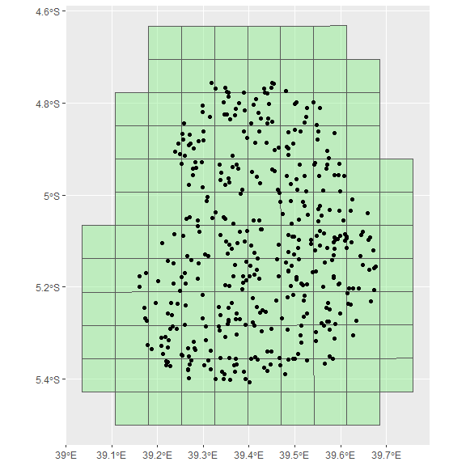

data points overlaid on grids

```r
ggplot() +
  geom_sf(data = grids, fill = "lightgreen", alpha = .2) +
  geom_sf(data = data.points) +
  scale_fill_gradientn(name = "Events",colours = oce::oce.colorsPalette(120))
```

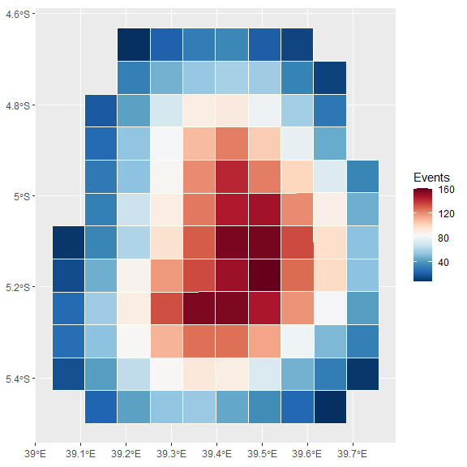

```r
obs = ggplot() +
  geom_sf(data = grids, aes(fill = nbObs), color = "ivory") +
  scale_fill_gradientn(name = "Events",colours = oce::oce.colorsPalette(120))

obs
```

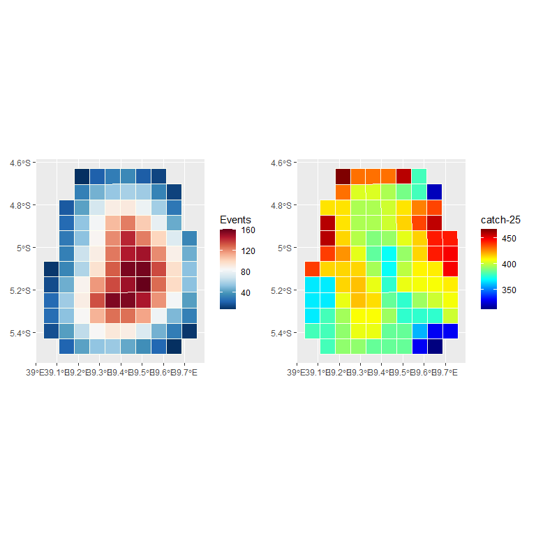

```r
catch25 = ggplot() +
  geom_sf(data = grids %>% filter(quantile == "0.25"), aes(fill = data), color = "ivory") +
  scale_fill_gradientn(name = "catch-25",colours = oce::oce.colors9A(120))

obs + catch25
```

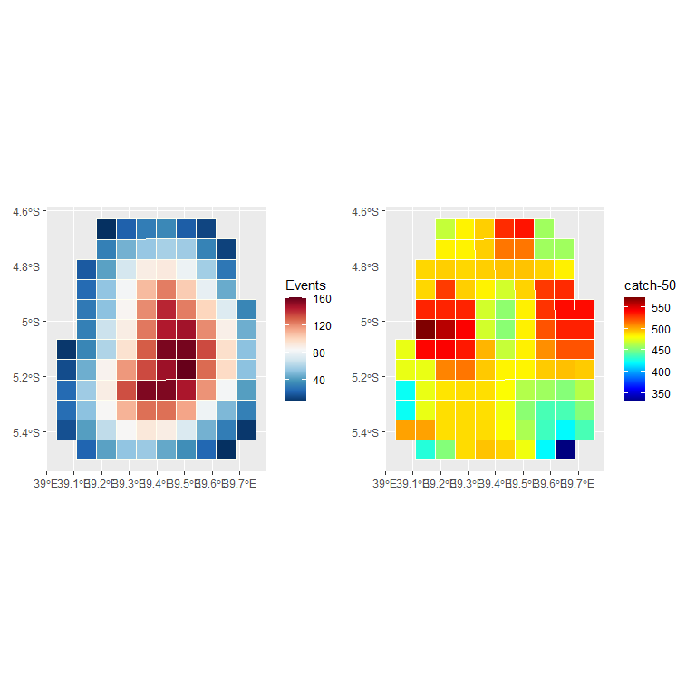

```r
catch50 = ggplot() +
  geom_sf(data = grids %>% filter(quantile == "0.5"), aes(fill = data), color = "ivory")+
  scale_fill_gradientn(name = "catch-50", colours = oce::oce.colors9A(120))

obs + catch50
```

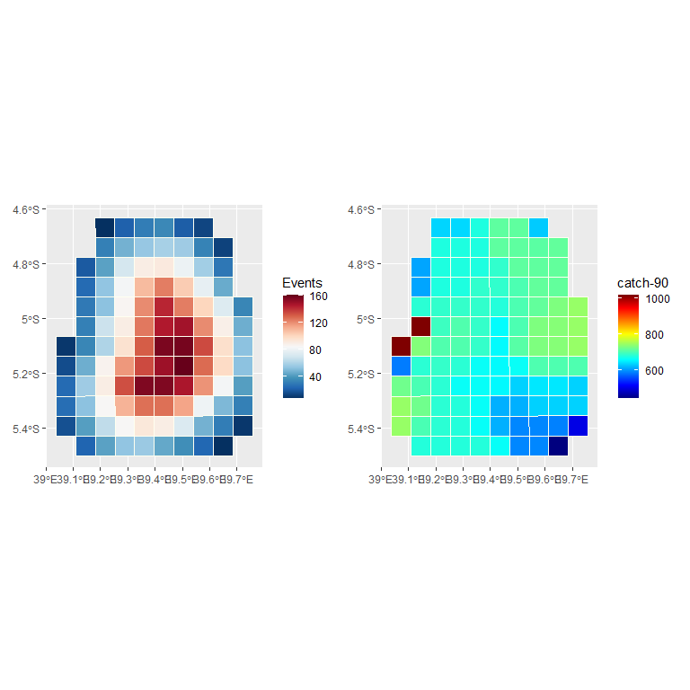

```r
catch90 = ggplot() +
  geom_sf(data = grids %>% filter(quantile == "0.9"), aes(fill = data), color = "ivory")+
  scale_fill_gradientn(name = "catch-90",colours = oce::oce.colors9A(120))

obs + catch90
```

# 2 Converting simple feature to tibble

Sometimes you may wish to work in tibble. However, the only dataset you have is simple feature. Though the simple feature contain attributes information that describe or characterize the feature. But when you may want to only remain with the tibble with their geographical position and drop the geometry attributes in simple feature. The **wior** package has two functions that can assist you with this

## 2.1 Change point to tibble

As the name of `point_tb` imply, this function change point feature into a tible dataset. let us see how

First we explore the dataset

```r
data("sample_data")
data.points
```

```
#> Simple feature collection with 400 features and 1 field
#> geometry type:  POINT
#> dimension:      XY
#> bbox:           xmin: 39.16012 ymin: -5.407592 xmax: 39.67618 ymax: -4.755428
#> geographic CRS: WGS 84
#> First 10 features:
#>                      geometry    catch
#> 1  POINT (39.20854 -5.327531) 616.9587
#> 2   POINT (39.3331 -5.244022) 516.9331
#> 3   POINT (39.35663 -5.19814) 278.5218
#> 4  POINT (39.43465 -4.777303) 587.1892
#> 5   POINT (39.4015 -5.407592) 505.4878
#> 6  POINT (39.22234 -5.332347) 696.7090
#> 7  POINT (39.35733 -5.354696) 498.4515
#> 8   POINT (39.3377 -5.354736) 586.6493
#> 9  POINT (39.51725 -5.195405) 471.2325
#> 10 POINT (39.27373 -5.359452) 606.1214
```

It is a simple feature with one variable (i.e catch) and 400 observation. We also see that the coordinate information, which are in degree decimal are embedded in the geometry. Let us have a corresponding tibble from this simple feature with `point_tb` function

```r
point.tb = data.points %>%
  point_tb()

point.tb
```

```
#> # A tibble: 400 x 3
#>      lon   lat catch
#>    <dbl> <dbl> <dbl>
#>  1  39.2 -5.33  617.
#>  2  39.3 -5.24  517.
#>  3  39.4 -5.20  279.
#>  4  39.4 -4.78  587.
#>  5  39.4 -5.41  505.
#>  6  39.2 -5.33  697.
#>  7  39.4 -5.35  498.
#>  8  39.3 -5.35  587.
#>  9  39.5 -5.20  471.
#> 10  39.3 -5.36  606.
#> # ... with 390 more rows
```

## 2.2 Polygon to tibble

The other function that **wior** package offers is to change from polygon to tibble. This happens sometimes when you want for instance to map and label polygon. You need to extract the centroid point of each polygon and then stitch the attributes to them for you to label them on the map. Let us use a simple feature that represent 51 countries of Africa.

```r
africa
```

```
#> Simple feature collection with 51 features and 10 fields
#> geometry type:  MULTIPOLYGON
#> dimension:      XY
#> bbox:           xmin: -17.62504 ymin: -34.81917 xmax: 51.13387 ymax: 37.34999
#> geographic CRS: WGS 84
#> # A tibble: 51 x 11
#>    iso_a2 name_long continent region_un subregion type  area_km2     pop lifeExp
#>  * <chr>  <chr>     <chr>     <chr>     <chr>     <chr>    <dbl>   <dbl>   <dbl>
#>  1 TZ     Tanzania  Africa    Africa    Eastern ~ Sove~  932746.  5.22e7    64.2
#>  2 EH     Western ~ Africa    Africa    Northern~ Inde~   96271. NA         NA
#>  3 CD     Democrat~ Africa    Africa    Middle A~ Sove~ 2323492.  7.37e7    58.8
#>  4 SO     Somalia   Africa    Africa    Eastern ~ Sove~  484333.  1.35e7    55.5
#>  5 KE     Kenya     Africa    Africa    Eastern ~ Sove~  590837.  4.60e7    66.2
#>  6 SD     Sudan     Africa    Africa    Northern~ Sove~ 1850886.  3.77e7    64.0
#>  7 TD     Chad      Africa    Africa    Middle A~ Sove~ 1271695.  1.36e7    52.2
#>  8 ZA     South Af~ Africa    Africa    Southern~ Sove~ 1216401.  5.45e7    61.0
#>  9 LS     Lesotho   Africa    Africa    Southern~ Sove~   27506.  2.15e6    53.3
#> 10 ZW     Zimbabwe  Africa    Africa    Eastern ~ Sove~  376328.  1.54e7    59.4
#> # ... with 41 more rows, and 2 more variables: gdpPercap <dbl>,
#> #   geom <MULTIPOLYGON [°]>
```

You notice that is a multipolygon, to turn this into tibble, we use a `polygon_tb` function

```r
africa.tb = africa %>%
  polygon_tb()
africa.tb
```

```
#> # A tibble: 51 x 12
#>      lon     lat iso_a2 name_long continent region_un subregion type  area_km2
#>    <dbl>   <dbl> <chr>  <chr>     <chr>     <chr>     <chr>     <chr>    <dbl>
#>  1  34.8  -6.26  TZ     Tanzania  Africa    Africa    Eastern ~ Sove~  932746.
#>  2 -12.1  24.3   EH     Western ~ Africa    Africa    Northern~ Inde~   96271.
#>  3  23.6  -2.85  CD     Democrat~ Africa    Africa    Middle A~ Sove~ 2323492.
#>  4  45.7   4.75  SO     Somalia   Africa    Africa    Eastern ~ Sove~  484333.
#>  5  37.8   0.596 KE     Kenya     Africa    Africa    Eastern ~ Sove~  590837.
#>  6  29.9  16.0   SD     Sudan     Africa    Africa    Northern~ Sove~ 1850886.
#>  7  18.6  15.3   TD     Chad      Africa    Africa    Middle A~ Sove~ 1271695.
#>  8  25.0 -28.9   ZA     South Af~ Africa    Africa    Southern~ Sove~ 1216401.
#>  9  28.2 -29.6   LS     Lesotho   Africa    Africa    Southern~ Sove~   27506.
#> 10  29.8 -18.9   ZW     Zimbabwe  Africa    Africa    Eastern ~ Sove~  376328.
#> # ... with 41 more rows, and 3 more variables: pop <dbl>, lifeExp <dbl>,
#> #   gdpPercap <dbl>
```

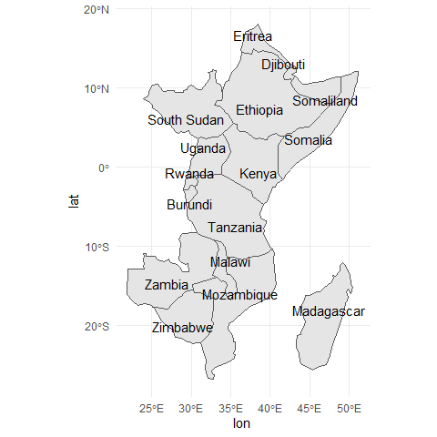

```r
ggplot() +
  geom_sf(data = africa %>% filter(subregion == "Eastern Africa")) +
  ggrepel::geom_text_repel(data = africa.tb %>% filter(subregion == "Eastern Africa"),
                           aes(lon,lat, label = name_long))+
  theme_minimal()
```